# Perceptual Phenomenon

### 1. What is our independent variable? What is our dependent variable?

Independent Variable: wether color and name font are similar or not

Dependent Variable: Reaction time to answer.

### 2. What is an appropriate set of hypotheses for this task? What kind of statistical test do you expect to perform? Justify your choices.

Same font color and name, less reaction time. It will be a t-Test in order to find out if the difference is significant.

### 3. Report some descriptive statistics regarding this dataset. Include at least one measure of central tendency and at least one measure of variability.

```python
import pandas as pd

path = '/Users/dgcagigas/Documents/DataAnalyzer/P1/stroopdata.csv'
dataFrame = pd.read_csv(path) #All data
dataFrame
```

|  | Congruent | Incongruent |
| --- | --- | --- |
| 0 | 12.079 | 19.278 |
| 1 | 16.791 | 18.741 |
| 2 | 9.564 | 21.214 |
| 3 | 8.630 | 15.687 |
| 4 | 14.669 | 22.803 |
| 5 | 12.238 | 20.878 |
| 6 | 14.692 | 24.572 |
| 7 | 8.987 | 17.394 |
| 8 | 9.401 | 20.762 |
| 9 | 14.480 | 26.282 |
| 10 | 22.328 | 24.524 |
| 11 | 15.298 | 18.644 |
| 12 | 15.073 | 17.510 |
| 13 | 16.929 | 20.330 |
| 14 | 18.200 | 35.255 |
| 15 | 12.130 | 22.158 |
| 16 | 18.495 | 25.139 |
| 17 | 10.639 | 20.429 |
| 18 | 11.344 | 17.425 |
| 19 | 12.369 | 34.288 |
| 20 | 12.944 | 23.894 |
| 21 | 14.233 | 17.960 |
| 22 | 19.710 | 22.058 |
| 23 | 16.004 | 21.157 |

It's clear that the reaction time with incongruent colors is bigger than congruent. Now we'll calculate the central tendency values. Mean and median. Mode is irrelevant. \begin{equation*} Mean => \bar{x}=\sum x_i/n\ Median => intermediate value(sorted) \end{equation*}

```python
Mean = dataFrame.mean();
#Mean
Mean
```

```
Congruent      14.051125
Incongruent    22.015917
dtype: float64
```

```python
Median = dataFrame.median();
#Median
Median
```

```
Congruent      14.3565
Incongruent    21.0175
dtype: float64
```

\begin{equation*} Variance => \sigma^2 = \sum (x_i-\bar{x})^2/n\\ Standard\ deviation => \sigma = \sqrt{\sum (x_i-\bar{x})^2/n} \end{equation*}

```python
Variance = dataFrame.var();
#Variance
Variance
```

```
Congruent      12.669029
Incongruent    23.011757
dtype: float64
```

```python
SD = dataFrame.std();
#Standard deviation
SD
```

```
Congruent      3.559358
Incongruent    4.797057
dtype: float64
```

### 4. Provide one or two visualizations that show the distribution of the sample data. Write one or two sentences noting what you observe about the plot or plots.

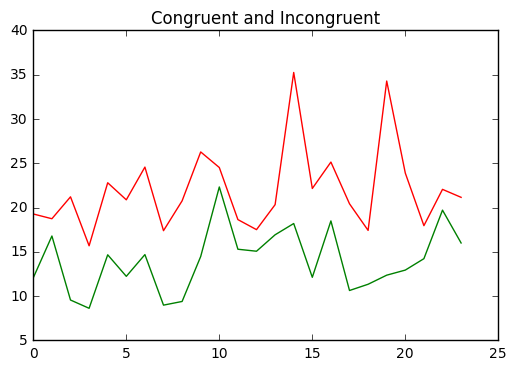

```python
# Causes plots to display within the notebook rather than in a new window
%pylab inline

import matplotlib.pyplot as plt

plt.plot(dataFrame['Congruent'],'green')

plt.plot(dataFrame['Incongruent'],'red')

plt.title("Congruent and Incongruent")
plt.show()
```

All participants took longer to answer incongruent data.

### 5. Now, perform the statistical test and report your results. What is your confidence level and your critical statistic value? Do you reject the null hypothesis or fail to reject it? Come to a conclusion in terms of the experiment task. Did the results match up with your expectations?

\begin{equation*} H_o = Congruent\ and\ incongruent\ reaction\ times\ do\ not\ differ.\ \mu_c=\mu_i\\ H_A = Congruent\ and\ incongruent\ reaction\ times\ do\ differ.\ \mu_c<\mu_i\\ t = \frac{\bar{x}-\mu}{SE}\\ SE = \frac{SD} {\sqrt{n}} \end{equation*}

We'll suppose a confidence level of 0.05. We will conduct a one-tailed test, as the incongruent test will have larger reaction time as congruent.

Using the t-table, the t-critical value at an alpha level of 0.05 with df=23 t=1.714

```python
DMean=(Mean['Congruent']-Mean['Incongruent']);
DMean
```

```
-7.9647916666666649
```

And the new standard deviation will be \begin{equation*} S_D = \sqrt{S_1^2 + S_2^2} \end{equation*}

```python
DSD=sqrt(pow(SD['Congruent'],2)+pow(SD['Incongruent'],2));
DSD
```

```
5.9733396108779937
```

\begin{equation*} t=\frac{\bar{x}_D}{S_D/\sqrt{n}} \end{equation*}

```python
n=24;
t=DMean/(DSD/sqrt(n))
t
```

```
-6.5322505539032258
```

I reject null Hypothesis, as t statistic is bigger than t critical. Concerning the t statistic value, incongruent test is very unlikely(probability circa 0) to get a mean result as in congruent test. So as I expected font color is more important at a first sight than the words.

### 6. Optional: What do you think is responsible for the effects observed? Can you think of an alternative or similar task that would result in a similar effect? Some research about the problem will be helpful for thinking about these two questions!

It's easier for our brain to process colors that words. I guess that you can cheat your brain in the same way listening the word instead of reading.